# Motivación

Twitter: @pablohaya

Correo-e: Pablo.Haya@uam.es

`intro-r` es un curso de introductorio al lenguaje de programación R que incluye manipulación y visualización de datos.

## ¿Qué es R?

`R` es un lenguaje de programación específico para análisis, manipulación y visualización de datos.

Incluye de serie una potente y completa variedad de funciones estadísticas, y dispone de más de [15.000 paquetes adicionales](https://www.rdocumentation.org/) que resuelven problemas de diversa índole (ej. [psicometría](https://www.rdocumentation.org/taskviews#Psychometrics), [econometría](https://www.rdocumentation.org/taskviews#Econometrics), [machine learning](https://www.rdocumentation.org/taskviews#MachineLearning), [series temporales](https://www.rdocumentation.org/taskviews#TimeSeries), [bioinformática](https://www.bioconductor.org/)…).

`R` es código abierto y de uso gratuito. Se [encuentra disponible](https://www.r-project.org/) para una amplia variedad de plataformas UNIX, para Windows y MacOS.

## ¿Desde cuándo existe R?

`R` tiene como percursor el lenguaje de programación `S` que fue creado por el estadístico [John Chambers](https://statistics.stanford.edu/people/john-chambers) en 1976 dentro de los míticos Bell Labs.

Chambers recibe en 1998 el prestigioso premio [ACM Sotfware System Award](https://en.wikipedia.org/wiki/ACM_Software_System_Award) por el desarrollo de sistemas software de reconocida y duradera influencia.

`R` fue creado por [Ross Ihaka](https://www.stat.auckland.ac.nz/~ihaka/) y Robert Gentleman, profesores de estadística de la Universidad Auckland, New Zealand en 1992.

Figuras relevantes que están contribuyendo significativamente al desarrollo y expansión del lenguaje son: [Hadley Wickham](http://hadley.nz/), [Yihui Xie](https://yihui.name/en/), y [Kirill Müller](http://krlmlr.github.io/) entre otros.

## ¿Por qué usar R?

R aporta a un proyecto de análisis de datos tres características fundamentales: **replicabilidad**, **amplitud**, y **libertad**.

Otros lenguajes de programación estadística son SAS, SPSS, ó Stata. Todos ellos son distribuidos por distintas empresas bajo licencia comercial.

`R` es un lenguaje consolidado con de 20 años de historia que sigue creciendo su uso exponencialmente.

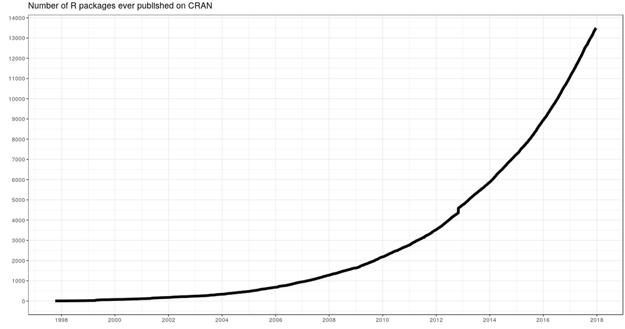

Fuente: imagen creada por usando un [script](https://gist.github.com/daroczig/3cf06d6db4be2bbe3368#file-get-data-r) de Gergely Daróczi

En el mundo académico se está convirtiendo en un estándar de-facto para la realización de análisis estadísticos, visualización y difusión de resultados que está desbancando a SPSS.

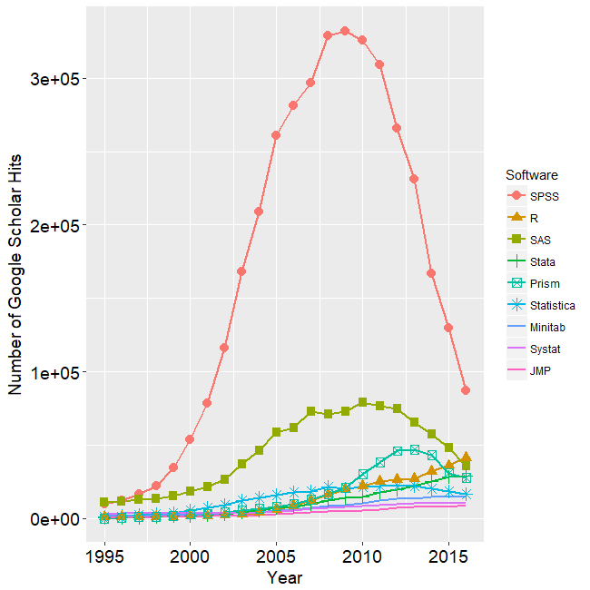

Fuente: [The Popularity of Data Science Software](http://r4stats.com/articles/popularity/) en r4stats.com

En la industria, la tendencia es que `R` le ha ido ganando terreno a SAS llegándole a superar en popularidad. La siguiente gráfica extraida de [r4stats](http://r4stats.com) muestra la evolución de la demanda del empleo para ambos lenguajes.

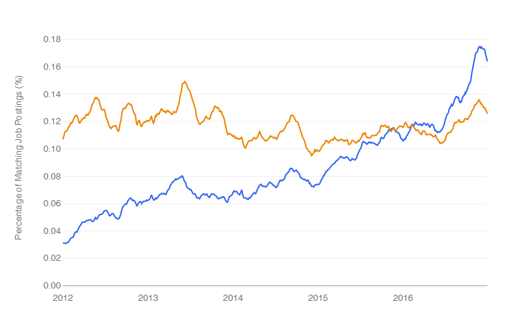

Fuente: [The Popularity of Data Science Software](http://r4stats.com/articles/popularity/) en r4stats.com

Actualmente `R` se encuentra las primeras posiciones de las listas más importantes sobre lenguajes de programación, con el añadido de ser un lenguaje de nicho (ej. séptima posición en el [The 2018 Top Programming Languages](https://spectrum.ieee.org/at-work/innovation/the-2018-top-programming-languages) de IEEE Spectrum).

La siguiente gráfica compara número de proyectos en github, el repositorio de software libre más popular, y popularidad en stackoverflow, el portal más importante de preguntas-respuestas sobre lenguajes de programación.

[figure not shown]

Fuente: [The RedMonk Programming Language Rankings: June 2018](https://redmonk.com/sogrady/2018/08/10/language-rankings-6-18/) en https://redmonk.com

## ¿Quién usa R?

Grandes compañias como Microsoft han apostado fuerte por `R`. Microsoft mantiene su propia versión del intérprete del lenguaje [Microsoft Open R](https://mran.microsoft.com/open), y su propio [repositorio de paquetes](https://mran.microsoft.com/) basado en CRAN.

IBM también integra `R` en sus productos orientados a ciencia de datos como IBM Data Science Experience.

`R` es un lenguaje popular en las ramas de estadística, bioinformática, y ciencias sociales, así como entre la comunidad de científicos de datos donde comparte espacio con Python.

## Temario del curso

- Preparacion: instalación y configuración del entorno (html)

### Primera parte

- Primeros pasos (html)
- Vectores (html)
- Factores (html)
- *Data Frames* ó tablas (html)

### Segunda parte

- Leer y escribir (html)
- Manipulación de datos (html)
- Agregar y resumir (html)
- Visualizar (html)

## Enlaces y material adicional

- https://www.r-project.org/: página oficial del lenguaje.
- https://cran.rediris.es/: repositorio de paquetes en España.
- https://www.rdocumentation.org/: página con la documentación de los paquetes.
- https://github.com/trending/r?since=monthly: paquetes de `R` más populares en github.
- http://r-bloggers.com: portal más importante sobre noticias y tutoriales de `R`
- https://stackoverflow.com/questions/tagged/r: preguntas y respuestas sobre `R` en stackoverflow
- https://twitter.com/search?q=%23rstats: tuits con el hashtag #rstats

## Libros, tutoriales y ejemplos

### Libros

- [R for Data Science](http://r4ds.had.co.nz/) referencia básica por el mayor experto actual en `R`.
- [R in Action](https://www.manning.com/books/r-in-action) libro del autor del port Quick-R.
- [The R Book](https://www.cs.upc.edu/~robert/teaching/estadistica/TheRBook.pdf): todo sobre `R`
- [An Introduction to Statistical Learning](http://www-bcf.usc.edu/~gareth/ISL/ISLR%20First%20Printing.pdf): libro fundamental par introducirse al machine learning con `R`.

### Ejemplos

- [R Studio Cheatsheets](https://www.rstudio.com/resources/cheatsheets/): resúmenes con comandos básicos de distintas funcionales y herramientas que usan `R`.
- [Quick-R](https://www.statmethods.net/index.html): portal con ejemplos y tutoriales sencillos.

### Cursos

- [R Programming](https://www.coursera.org/learn/r-programming) en Coursera.
- [Introduction to R for Data Science](https://www.edx.org/es/course/introduction-r-data-science) en Edx por Microsoft.
- [Introduction to R](https://www.datacamp.com/courses/free-introduction-to-r) en Datacamp.

## Licencia

El material de este repositorio se licencia bajo [Creative Commons Attribution 4.0 International License](http://creativecommons.org/licenses/by/4.0/).